# Introduction to Snakemake

A short overview using examples

Author

Florian Geier (florian.geier@unibas.ch), Igor Cervenka (igor.cervenka@unibas.ch)

Published

April 21, 2026

# Introduction

## Why workflow managers?

Specialized analysis vs. **repetitive analysis across projects/over time**

- Avoid redundancy: when adding data sets and/or when resuming from failures
- Handle parallelization: execute for tens to thousands of data sets
- Work reproducible: formalized the workflow, include tool versioning and possibly deployment

## What is Snakemake?

- [Snakemake](https://snakemake.readthedocs.io/en/stable/index.html) is a python based workflow tool inspired by [GNU make](https://www.gnu.org/software/make/) but with significant enhancements:
  - Highly readable mini-language
  - Adaptable due to modular organization: rules, wrappers, sub-workflows
  - Extended support for many scripting languages (bash, R, markdown etc.)
  - Clever job scheduling
  - Scaleable to different computational resources: server, cluster and cloud
  - Portable by self-contained management of software stack via conda

## How to get it?

- Pre-requisite: get conda via miniforge https://github.com/conda-forge/miniforge and follow the installation instructions.
- Set up a conda configuration file (`$HOME/.condarc`), listing the following channel order to pick packages from:

```
.condarc
```

```yaml
channels:
  - conda-forge
  - bioconda
channel_priority: strict
auto_activate: false # don't activate base environment by default
```

**Important**

- Don’t use the proprietary Anaconda (`defaults`) channel
- Use strict channel priority to enhance reproducibility of software environments

**TipWhich snakemake version shall I use?**

Snakemake is actively developed with new minor versions changes within hours or days. Major updates involve breaking changes, while minor changes fix bugs and enhance features. In this tutorial we assume version 8.30 i.e. the last release of major version 8.

- Use conda to install snakemake:

```bash
conda create -n snakemake_8 snakemake=8.30 snakemake-executor-plugin-cluster-generic
```

- The additional package `snakemake-executor-plugin-cluster-generic` is required in order to use the slurm profile (see below)
- Now, activate the environment with:

```bash
conda activate snakemake_8
```

# Example workflow: read alignment and gene counting

You can find all example code in our [repository](https://github.com/dbmbcf/SnakemakeTutorial)

## Set up Snakefile

- A `Snakefile` is a collection of rules defined in the Snakemake mini-language.
- Each rule describes how to create a (set of) output file(s) from a (set of) input file(s).
- Dependencies between rule-derived jobs are implicitly encoded via matching of file name patterns.

```
Example 1: Snakefile
```

```python
rule align:
    input: "sample.fq.gz"
    output: "sample.bam"
    shell: "do the alignment..."

rule count:
    input: "sample.bam"
    output: "counts.txt"
    shell: "do the counting..."

rule DGEList:
    input: "counts.txt"
    output: "dgel.rds"
    script: "create a DGEList object in R..."
```

- This dummy example doesn’t do anything, but highlights how fixed file name patterns connect the different rules into one workflow. It also assumes that the file `sample.fq.gz` is present.
- Invoking Snakemake on this first example requires to specify the desired output (=final target):
  - Runs only alignment step

```bash
snakemake -n sample.bam
```

```
- Runs alignment and counting
```

```bash
snakemake -n counts.txt
```

```
- Runs all three steps
```

```bash
snakemake -n dgel.rds
```

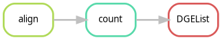

**Note**

- Note, all these cases were dry-runs (flag `-n`), since we didn’t provide any functionality to the individual steps .

## Generalize workflows with wildcards and configuration

```
Example 2: Snakefile
```

```python
configfile: "config.yaml"

rule all:
    input: "results/dgel.rds"

rule align:
    input: "../fastq/{sample}.fq.gz"
    output: "results/bam/{sample}.bam"
    shell: "do the alignment..."

rule count:
    input: "results/bam/{sample}.bam"
    output: "results/counts/{sample}.txt"
    shell: "do the counting..."

rule DGEList:
    input: expand("results/counts/{sample}.txt", sample=config['samples'])
    output: "results/dgel.rds"
    script: "create a DGEList object in R..."
```

- In order to generalize rules, Snakemake allows to use wildcards in input and output file names.
- Wildcards follow a few basic principles:
  - They are rule specific
  - In order to propagate wildcard matches from output to input files (and to the variable `wildcards`) they have to be named the same in input and output (and params etc.)
  - Not all output wildcards must be present in input
  - Wildcards can be constrained with the keyword `wildcard_constraints`

**Note**

- For example, all files in the fastq folder will be matched by the input pattern of rule `align`:

```bash
fastq/
├── rna_1.fq.gz
├── rna_2.fq.gz
└── rna_3.fq.gz
```

(Note: In the example above the fastq file paths are written relative to the Snakefile)

- A globally available `config` dictionary hosts all workflow configurations. It can be filled with values from the command line or by reading from separate [YAML files](https://yaml.org/), such as `config.yaml`:

```
config.yaml
```

```yaml
samples: ["rna_1", "rna_2", "rna_3"]
```

- The expression `expand("counts/{sample}.txt", sample=config['samples'])` allows to gather input files. It is a shortcut for a [python list comprehension](https://docs.python.org/3/tutorial/datastructures.html#list-comprehensions).
- The first rule of a Snakefile (often called rule `all`) plays a special rule: if no target is specified via the command line Snakemake assumes the input of the first rule is the required target (in our case `results/dgel.rds`)
- Calling `snakemake -n` on the example will therefore produce a workflow from alignment till DGEList creation.

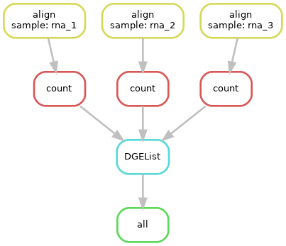

**Note**

The workflow DAG can be visualized with the help of `dot` which is part of the [graphviz](https://graphviz.org/) package. On sciCORE its available as a software module e.g. Graphviz/13.1.2-GCCcore-14.3.0.

```bash
snakemake --dag | dot -Tpdf > dag.pdf
## or landscape mode
snakemake --dag | dot -Tpdf -Grankdir=LR > dag.pdf
```

- Specifying samples via command line allows to overwrite the settings in `config.yaml`:

```bash
snakemake -n --config samples=[rna_2]
```

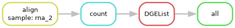

## Run commands in `shell` and `script` directives

- In order to be functional we need to fill the `shell` and `script` directives of each rule with appropriate calls of the software tools.

```
Example 3: Snakefile
```

```python
configfile: "tools.yaml"
configfile: "config.yaml" # merged into tools dictionary; allows to overwrite defaults in tools.yaml

rule all:
    input: "results/dgel.rds"

rule align:
    input: "../fastq/{sample}.fq.gz"
    output: "results/bam/{sample}/Aligned.sortedByCoord.out.bam"
    params:
        index = config["star"]["index"],
        options = config["star"]["options"]
    threads:
        4
    envmodules: "STAR/2.7.10b-GCC-11.3.0"
    shell:
        """
        STAR --genomeDir {params.index} --runThreadN {threads} {params.options} --readFilesIn {input} --outFileNamePrefix results/bam/{wildcards.sample}/
        """

rule count:
    input: "results/bam/{sample}/Aligned.sortedByCoord.out.bam"
    output: "results/counts/{sample}.txt"
    params:
        gtf = config["gtf"],
        extra = config["feature_counts"]["options"]
    envmodules: "Subread/2.0.6-GCC-11.3.0"
    shell:
        """
        featureCounts -a {params.gtf} -o {output} {params.extra} {input}
        """

rule DGEList:
    input: expand("results/counts/{sample}.txt", sample=config['samples'])
    output: "results/dgel.rds"
    log: "log/dgelist.log"
    params:
        names = config['samples']
    envmodules: "R/4.5.2-gfbf-2025b-bare"
    script: "scripts/create_dge_list.R"
```

- The `shell` directive is used for code running in bash (strict mode). It can access all local and global variables (`wildcards`, `input`, `output` etc.)
- The `params` slot allows to handle additional rule-specific parameters such as the STAR index or tool options. In our example, these options are taken from another configuration file (`tools.ymal`):

```
tools.yaml
```

```yaml
star:
  index: "/scicore/home/ivanek/GROUP/snakemake_genomes/mm10/STAR/"
  options: "--outSAMtype BAM SortedByCoordinate --readFilesCommand zcat"
feature_counts:
  options: "-O -M --primary"
r_lib: "/scicore/home/ivanek/GROUP/R-libraries/4.4.2-gfbf-2024a-bare-bioc-3.20"
```

- Snakemake offers special support for a couple of [scripting languages](https://snakemake.readthedocs.io/en/stable/snakefiles/rules.html#snakefiles-external-scripts)
- R scripts will be wrapped with code to make local and global variables transparent in a `snakemake` object, such as `input`, `output`, `params`, `wildcards` or `config`
- By that users can omit writing command line parsers for their scripts. E.g. within the `create_dge_list.R` script:

```
create_dge_list.R
```

```r
.libPaths(c(snakemake@params[["r_lib"]], .libPaths()))
library(edgeR)

res <- lapply(snakemake@input, function(fn) {
    df <- read.table(fn, header=TRUE, row.names=1)
    df[,ncol(df),drop=FALSE]
})

mat <- do.call('cbind', res)

colnames(mat) <- snakemake@params[["names"]]

dgel <- DGEList(counts=mat)

saveRDS(dgel, file=snakemake@output[[1]])
```

- R scripts will be called via `Rscript --vanilla`, i.e. all user-specific settings (`.Rprofile` etc.) are not interpreted

**Important**

Since the sciCORE environment module doesen’t provide the `edgeR` package, our example needs a specific R library path in order to be functional. We don’t recommend to use R in this way as it disrupts the link between R version and R library! Instead use R via conda deployment as explained below.

**Tip**

In order to redirect messages to a rule-specific log file you can add at the beginning of an R script the following lines:

```r
log <- file(snakemake@log[[1]], open = "wt")
sink(log, type="output")
sink(log, type="message")
```

This requires a `log` directive in the rule!

- Via `threads` one can assign multiple cores to a rule and also parallelize the execution of rules. As we run Snakemake locally `threads` will be adjusted to the number of cores made available via he command line (`-c` flag)
- As workflow now depends on external tools (STAR, featureCounts and R), these must be available on the command line. sciCORE provides a few software modules, which can be called on a per-rule basis using the `envmodules` statement.

**Note**

We do not recommend to use sciCORE modules, due to limited R/python package availability and lack of workflow portability. Instead, we recommend to use conda to deploy software environments (see below).

- Running Snakemake on the example require setting the command line flag `--software-deployment-method` or short `--sdm` to activate the sciCORE module system.
- Running Snakemake with 8 cores allows to run alignments in parallel:

```bash
snakemake --sdm env-modules -c 8
```

- Choosing just 2 cores will also run the `align` rule with just 2 threads:

```bash
snakemake --sdm env-modules -c 2
```

## Workflows are executed in three phases

1. Initialization phase
   - the Snakefile is parsed and all rules are instantiated (converted to python functions)
2. DAG phase
   - a directed acyclic graph (DAG) of jobs is built by filling wildcards and matching input files to output files
3. Scheduling phase
   - the DAG of jobs is executed taking job requirements (#CPS, memory, etc) into account

## Input functions

- Often wildcards are unknown (= cannot be decoded from file patterns) at initialization phase
- Rule specification can make use of input functions which defer determination of input files to the DAG phase, when wildcard values are known
- Using input function overrides the default mechanism of replacing wildcards with their values inferred from the output files. You have to take care of that yourself with the given wildcards object.
- In the example below samples are split over different numbers of sequencing lanes. We would like to merge alignment results across lanes with the help of `samtools`.

```
config.yaml
```

```yaml
samples: ["rna_1", "rna_2", "rna_3"]
groups:
  group1: ["rna_1", "rna_2"] # lane1 and 2
  group2: ["rna_3"] # lane 3
```

```
Example 4: Snakefile
```

```python
configfile: "tools.yaml"
configfile: "config.yaml" # merged into tools dictionary; allows to overwrite defaults in tools.yaml

rule all:
    input: "results/dgel.rds"

rule align:
    input: "../fastq/{sample}.fq.gz"
    output: "results/bam/{sample}/Aligned.sortedByCoord.out.bam"
    params:
        index = config["star"]["index"],
        options = config["star"]["options"]
    threads:
        4
    envmodules: "STAR/2.7.10b-GCC-11.3.0"
    shell:
        """
        STAR --genomeDir {params.index} --runThreadN {threads} {params.options} --readFilesIn {input} --outFileNamePrefix results/bam/{wildcards.sample}/
        """

rule merge:
    input: lambda wildcards: expand("results/bam/{sample}/Aligned.sortedByCoord.out.bam", sample=config['groups'][wildcards.group])
    output: "results/merged/{group}.bam"
    threads: 2
    envmodules: "SAMtools/1.20-GCC-13.2.0"
    shell:
        """
        samtools merge --threads {threads} {output} {input}
        """

rule count:
    input: "results/merged/{sample}.bam"
    output: "results/counts/{sample}.txt"
    params:
        gtf = config["gtf"],
        extra = config["feature_counts"]["options"]
    envmodules: "Subread/2.0.6-GCC-11.3.0"
    shell:
        """
        featureCounts -a {params.gtf} -o {output} {params.extra} {input}
        """

rule DGEList:
    input: expand("results/counts/{sample}.txt", sample=config['groups'])
    output: "results/dgel.rds"
    log: "log/dgelist.log"
    params:
        r_lib = config['r_lib'],
        names = config['groups']
    envmodules: "R/4.5.2-gfbf-2025b-bare"
    script: "scripts/create_dge_list.R"
```

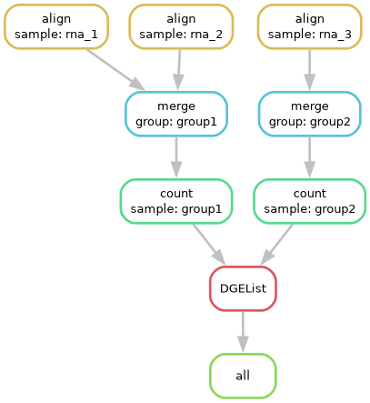

## Manage tools via software environment definitions

- Snakemake supports rule-specific software deployment via the package manager [conda](https://docs.conda.io/en/latest/). Thus, each job is run in a separate, self-contained software environment.

```
Example 5: Snakefile
```

```python
configfile: "tools.yaml"
configfile: "config.yaml" # merged into tools dictionary; allows to overwrite defaults in tools.yaml

rule all:
    input: "results/dgel.rds"

rule align:
    input: "../fastq/{sample}.fq.gz"
    output: "results/bam/{sample}/Aligned.sortedByCoord.out.bam"
    params:
        index = config["star"]["index"],
        options = config["star"]["options"]
    threads:
        4
    conda: "envs/star.yaml"
    shell:
        """
        STAR --genomeDir {params.index} --runThreadN {threads} {params.options} --readFilesIn {input} --outFileNamePrefix results/bam/{wildcards.sample}/
        """

rule samtools_merge:
    input: lambda wildcards: expand("results/bam/{sample}/Aligned.sortedByCoord.out.bam", sample=config['groups'][wildcards.group])
    output: "results/merged/{group}.bam"
    threads: 2
    conda: "envs/samtools.yaml"
    shell:
        """
        samtools merge --threads {threads} {output} {input}
        """

rule count:
    input: "results/merged/{sample}.bam"
    output: "results/counts/{sample}.txt"
    params:
        gtf = config["gtf"],
        extra = config["feature_counts"]["options"]
    conda: "envs/subread.yaml"
    shell:
        """
        featureCounts -a {params.gtf} -o {output} {params.extra} {input}
        """

rule DGEList:
    input: expand("results/counts/{sample}.txt", sample=config['groups'])
    output: "results/dgel.rds"
    params:
        names = config['groups']
    conda: "envs/r_edger.yaml"
    script: "scripts/create_dge_list.R"
```

- The `conda` directive points to an environment definition which is written in simple YAML file such as:

**Important**

Note the channel order: 1. conda-forge, 2. bioconda

```
star.yaml
```

```yaml
channels:
 - conda-forge
 - bioconda
dependencies:
 - star = 2.7.10b
```

- The [bioconda channel](https://anaconda.org/bioconda/) is dedicated to bioinformatics software. Check it to figure out available tool releases!

```
r_bioc.yaml
```

```yaml
channels:
 - conda-forge
 - bioconda
dependencies:
 - r-base = 4.5.2
 - bioconductor-biocversion = 3.22
 - bioconductor-edger
```

**Note**

Every Bioconductor release is tied together with a particular R version. The Bioconductor release cycle is twice per year (April and Oktober), while the R release cycle is once per year (April). Recent versions are:

- R 4.5.* and Bioc 3.22
- R 4.6.* and Bioc 3.23

**Note**

Running `snakemake --sdm conda --conda-create-envs-only` will only install the required conda environments without running the full workflow. Subsequent runs with `--sdm conda` will make use of the local environments without requiring internet access.

**Note**

- Any update of an environment definition will cause an update of all affected targets when re-running the workflow.

## Using Snakemake wrappers

- Alternatively, [wrappers](https://snakemake-wrappers.readthedocs.io/en/stable/) provide ready made definitions for software environments as well as shell directives that wrap calls to the command line.
- Wrappers are available for many popular tools at https://snakemake-wrappers.readthedocs.io/en/stable/wrappers.html
- Snakemake wrappers allow us to reuse pre-tested code rather than writing manual shell commands. However, using them requires specific attention to detail:
  - **Strict Structure**: Each wrapper expects specific names for input, output, and params. You must consult the official documentation (e.g. [STAR](https://snakemake-wrappers.readthedocs.io/en/stable/wrappers/bio/star/align.html)) to ensure your rule blocks match the wrapper’s requirements.
  - **Environment Management**: Wrappers include bundled Conda environments.
  - **Offline HPC Usage**: Because Slurm nodes often lack internet access, you must use a local clone of the wrapper repository.
- We have to make a few workflow adjustments to use wrappers:
  - Change the `shell:` directive to `wrapper:`. When using `--wrapper-prefix`, omit the version number and the initial slash (e.g., use `bio/star/align` instead of `v3.0.0/bio/star/align`).
  - Remote wrappers are versioned automatically. For local copies, you are responsible for managing the repository version.
  - Notice in this example that we rearranged inputs and outputs to satisfy the wrapper. We also removed redundant parameters (like `--readFilesCommand zcat`) from `tools.yaml` file already handled by the wrapper logic.

```
tools.yaml
```

```yaml
star:
  index: "/scicore/home/ivanek/GROUP/snakemake_genomes/mm10/STAR"
  options: "--outSAMtype BAM SortedByCoordinate"
feature_counts:
  options: "-O -M --primary"
```

```
Snakefile
```

```python
configfile: "config.yaml"
configfile: "tools.yaml"

rule all:
    input: "results/dgel.rds"

rule align:
    input:
        fq1="../fastq/{sample}.fq.gz",
        idx=config["star"]["index"],
    output:
         aln="results/bam/{sample}/Aligned.sortedByCoord.out.bam",
    params:
        extra = config["star"]["options"]
    threads: 4
    wrapper:
        "bio/star/align"

rule merge:
    input: lambda wildcards: expand("results/bam/{sample}/Aligned.sortedByCoord.out.bam", sample=config['groups'][wildcards.group])
    output: "results/merged/{group}.bam"
    threads: 2
    wrapper:
        "bio/samtools/merge"

rule count:
    input:
        samples="results/merged/{sample}.bam",
        annotation=config["gtf"],
    output:
        "results/counts/{sample}.txt",
    params:
        extra = config["feature_counts"]["options"]
    wrapper:
        "bio/subread/featurecounts"

rule DGEList:
    input: expand("results/counts/{sample}.txt", sample=config['groups'])
    output: "results/dgel.rds"
    params:
        names = config['groups']
    conda:
        "envs/r_edger.yaml"
    script:
        "scripts/create_dge_list.R"
```

- To use wrappers offline, point Snakemake to a local clone of the repository using the `--wrapper-prefix` flag.

```bash
snakemake -j 2 --sdm conda --wrapper-prefix /scicore/home/ivanek/GROUP/snakemake_wrappers/
```

## Run Snakemake on sciCORE slurm cluster

- A big benefit of Snakemake is to scale up/parallelize workflow execution by using cluster or cloud computing.
- Cluster or cloud back-ends require [resource](https://snakemake.readthedocs.io/en/stable/snakefiles/rules.html#resources) specifications for each job. This is achieved by the `resources` tag on a per rule basis.
- Depending on the back-end these could include temporary directory, disk space, required memory or run time.
- Resources can be set dynamically depending on the input (or params, wildcards etc.) using functions or lambda expressions:

```
Example 7: Snakefile
```

```python
rule align:
    input:
      fastq = "fastq/{sample}.fq.gz",
      index = os.path.join(config["star"]["index"], "SA")
    output: "bam/{sample}.bam"
    params:
        index_dir = config["star"]["index"],
        options = config["star"]["options"]
    threads:
        4
    resources:
        mem_mb = lambda wildcards, input: max(5000, input.size_mb + 5000),
        time = lambda wildcards, input: 30 if input.size_mb < 2000 else 360,
    conda: "envs/star.yaml"
    shell:
        """
        STAR --genomeDir {params.index_dir} --runThreadN {threads} {params.options} --readFilesIn {input.fastq} --outFileNamePrefix results/bam/{wildcards.sample}/
        """
```

- Ideally back-end specifications (e.g. slurm `qos`) are separated from workflow definitions via specific profiles. They tell Snakemake how to communicate with a specific back-end.
- Profiles contain:
  - a `config.yaml` file with default options for the Snakemake command line
  - a submit script that parses resource definitions of each job and constructs a submission command (slurm: `sbatch <options> <script>`)
  - a script which checks the job status (slurm: `sacct <jobid> <options>`) and reports it back to Snakemake
- We provide a sciCORE-specific slurm profile at https://git.scicore.unibas.ch/DBM_bioinfo/ivanek/snakemake/profiles/scicore-slurm.git. It offers a few sciCORE specific tweaks:
  - translate `time` to scicore-slurm `qos` settings
  - allow setting of group accounts
  - easy to extend to user needs
- When installed under `$HOME/.config/snakemake`, Snakemake can be invoked using the profile:

```bash
snakemake --profile slurm-profile # using local profile from example
```

- The `localrules` statement allows to select rules which are executed locally (in the submission node) instead of the cluster
- Execution of Snakemake wrappers need internet access, so rule `merge` must be a local rule

# Additional resources

- Running Snakemake paper https://f1000research.com/articles/10-33/v3
- Snakemake docs including long and short tutorials https://snakemake.readthedocs.io/en/stable/
- Official workflow repository https://github.com/snakemake-workflows
- Best practices https://snakemake.readthedocs.io/en/stable/snakefiles/best_practices.html
- Distribution and Reproducibility https://snakemake.readthedocs.io/en/stable/snakefiles/deployment.html

# Tasks for the workshop

## Task 1

Add a fastq filtering step using the fastp tool (on bioconda https://anaconda.org/bioconda/fastp). This tools allows among other things read trimming and adaptor removal.

## Task 2

A sample file lists all fastq files and corresponding samples (tsv format; path relative to Snakefile)

```
samples.tsv
```

```
FileName    SampleName
fastq/rna_1.fq.gz   sample_1
fastq/rna_2.fq.gz   sample_1
fastq/rna_3.fq.gz   sample_2
```

Create a python function which reads in the sample file and returns two dictionaries that can be used as rule inputs: 1. `fq_files`: which maps a file name to file path(s) 2. `samples`: which maps a sample name to file name(s)

## Task 3

Update the workflow to handle single as well as paired end data. A paired-end data example is in `fastq_paired`, the corresponding sample file looks like this:

```
samples.tsv
```

```
FileName1       FileName2       SampleName
rna_1_L1_R1.fq.gz       rna_1_L1_R2.fq.gz       rna_1
rna_1_L2_R1.fq.gz       rna_1_L2_R2.fq.gz       rna_1
rna_2_L1_R1.fq.gz       rna_2_L1_R2.fq.gz       rna_2
rna_2_L2_R1.fq.gz       rna_2_L2_R2.fq.gz       rna_2
rna_3_L1_R1.fq.gz       rna_3_L1_R2.fq.gz       rna_3
rna_3_L2_R1.fq.gz       rna_3_L2_R2.fq.gz       rna_3
```

- Hints:
  - Create a logical flag `PAIRED` that indicates if the data is paired-end
  - Either create distinct rules for single or paired-end data or use flexible input output definitions depending on the value of `PAIRED`. Since output directives don’t allow functions, you will need expressions like: `<input1> if PAIRED else <input2>`